# Sample waste stream analysis using the Waste Impact Calculator framework

This RMarkdown file provides an example of using the Waste Impact Calculator framework to calculate and compare the life cycle environmental impacts associated with solid waste management scenarios.

For example, you might want to compare the impacts associated with your current practice (the “baseline” scenario) with impacts for a scenario where you combust waste instead of landfill it, or a scenario where you recycle more.

This example involves R programming. If you don’t know R, or just want some quick ballpark results, consider using the “app” version of the Waste Impact Calculator, available through your web browser.

However, if you do know R, using it in an Rmarkdown file like this one will enable you to customize the output to your liking. This file serve as your starting point, but the sky’s the limit. Obviously, you are responsible for the credibility of any results.

INPUTS AND BASIC OPERATION

STRUCTURE OF THE MASS PROFILE FILE.

STRUCTURE OF THE IMPACT FACTOR FILE.

CHARACTERISTICS OF THE JOIN OPERATION.

SUMMING WEIGHTS AND IMPACTS

Once the detailed impact file has been created, it is important to remember that weights and impacts are summed in different ways.

DO STUFF NOW, DOCUMENTATION LATER!

import data confirm no factors calculate a summary “wasteshed” calculate detailed impacts calculate a few detailed strings for use later as factors then, for each chart, do the processing individually

LOADING PACKAGES

```r
library(tidyverse)  # contains many useful functions
```

```r
library(ggthemes)   # some themes for plotting
library(scales)     # more useful stuff for charts
library(rmarkdown)
library(viridis)
library(scales)
```

IMPORTING DATA

```r
massProfiles <-
  read.csv(
    file = "source_data/mass_profiles.csv",
    stringsAsFactors = FALSE
  )
impactFactors <-
  read.csv(
    file = "source_data/impact_factors.csv",
    stringsAsFactors = FALSE
  )
```

CREATING A SUMMARY WASTESHED

```r
# summing up the tons and miles for the existing wastesheds
temporaryMasses1 <-
  massProfiles %>%
  group_by(material, disposition, umbDisp, scenario) %>%
  summarise(
    tons = sum(tons),
    miles = mean(miles, na.rm = TRUE)
  ) %>%
  ungroup() %>%
  mutate(wasteshed="All cities")

massProfilesPlus <-
  bind_rows(massProfiles, temporaryMasses1) %>%
  arrange(scenario, wasteshed, material, disposition, umbDisp)

rm(temporaryMasses1)
rm(massProfiles)
```

CALCULATE DETAILED IMPACTS

```r
impactsInDetail <-
  left_join(
    massProfilesPlus,
    impactFactors,
    by = c("material", "disposition")
  ) %>%
  mutate(
    impact =
      case_when(
        LCstage != "endOfLifeTransport" ~ tons*impactFactor,
        LCstage == "endOfLifeTransport" ~
          tons*(miles/impliedMiles)*impactFactor
      )
  )
```

CALCULATE A FEW THINGS USEFUL FOR OUTPUT LATER

```r
# most abundant materials in the wastestream, in order
materialSortOrder <-
  massProfilesPlus %>%
  group_by(material) %>%
  summarise(tons=sum(tons)) %>%
  arrange(desc(tons)) %>%
  pull(material)
# a table of impact categories combined with units
# (for use in chart labels)
impactLabels <-
  impactFactors %>%
  select(impactCategory, impactUnits) %>%
  distinct() %>%
  mutate(
    impactLabel =
      paste(
        impactCategory,
        " (",
        impactUnits,
        ")",
        sep=""
      )
  )
# my own little graphic theme for charts, inspired by fivethirtyeight
theme_539 <- function() {
  theme_fivethirtyeight() +
  theme(
    rect=element_rect(fill="transparent"),
    panel.grid = element_blank(),
    axis.ticks = element_line()
  )
}

# making an ordered list of scenarios, where "baseline" is first
scenarioOrder <-
  c(
    "baseline",
    setdiff(
        massProfilesPlus %>%
        select(scenario) %>%
        distinct() %>%
        pull(scenario),
      "baseline")
  )
```

from this point on everything can be calculated with impactsInDetail.

I think the first thing users would want to know would be the final answers.

- what are the weights in all the scenarios?
- what are the impacts for all the scenarios?

```r
# summing weights by disposition for each scenario
tempWeightData1 <-
  impactsInDetail %>%
  filter(wasteshed == "All cities") %>% # just the total
  filter(LCstage == "endOfLife") %>% # correct set for weight calculations
  group_by(scenario, disposition) %>%
  summarise(tons=sum(tons)) %>%
  ungroup() %>%
  filter(tons != 0) %>%
  mutate(scenario= factor(scenario, levels=rev(scenarioOrder)))
```

making that weight data into a chart…

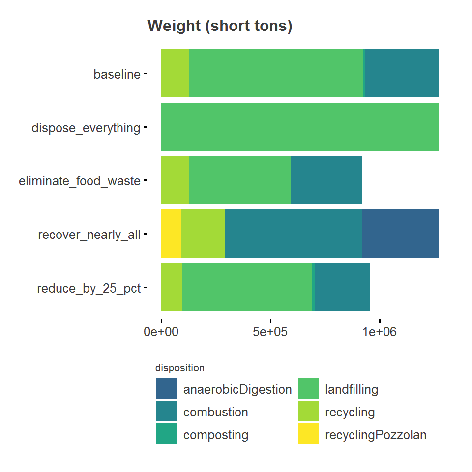

```r
tempWeightChart1 <-
  ggplot()+
  ggtitle("Weight (short tons)")+
  theme_539()+
  geom_bar(
    data = tempWeightData1,
    aes(x = scenario, y= tons, fill= disposition),
    color=NA,
    stat="identity"
  )+
  scale_fill_viridis(begin=0.32, end=1, discrete = TRUE)+
  coord_flip()+
  guides(fill=guide_legend(ncol=2, title.position = "top"))+
  theme(
    rect=element_rect(fill="transparent"),
    plot.title = element_text(size=12),
    legend.position="bottom",
    legend.title = element_text(size=8),
    legend.justification="left"
    )
tempWeightChart1
```

```r
ggsave("chart_output/weights.png")
```

Now for comparison, let’s look at the impacts associated with those scenarios. Because there are multiple impact categories, I’ll do a faceted chart.

```r
tempImpactData1 <-
  impactsInDetail %>%
  filter(wasteshed=="All cities") %>% # same filtering as weight chart
  group_by(scenario, impactCategory, impactUnits) %>%
  summarise(impact=sum(impact)) %>%
  ungroup() %>%
  mutate(
    scenario = factor(scenario, levels = rev(scenarioOrder)),
    impactLabel =
      paste(
        impactCategory,
        " (",
        impactUnits,
        ")",
        sep=""
      )
  ) %>%
  filter(impactCategory != "Energy demand") #removing to save space
```

now make that into a full-page chart

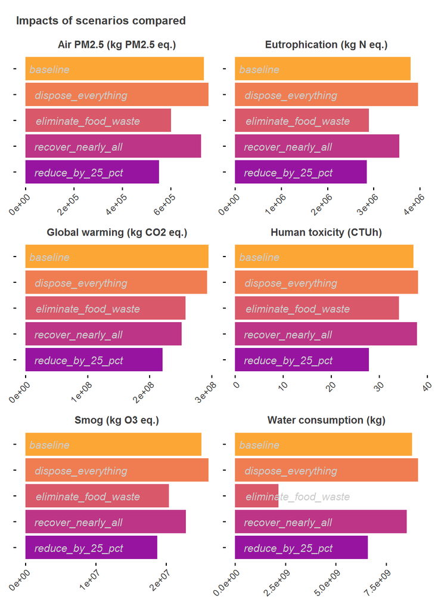

```r
tempImpactChart1 <-
  ggplot()+
  ggtitle("Impacts of scenarios compared")+
  theme_539()+
  geom_bar(
    data = tempImpactData1,
    aes(x = scenario, y= impact, fill=scenario),
    color=NA,
    # size=2,
    stat="identity"
  )+
  geom_text(
    data=tempImpactData1,
    aes(x=scenario, y=0, label=scenario),
    color="gray80",
    size=4,
    fontface="italic",
    hjust=-0.1
  )+
  facet_wrap(~impactLabel, ncol=2, scales="free")+
  scale_fill_viridis(
    begin=0.32, end=0.8, option="plasma", discrete = TRUE
  )+
  coord_flip()+
#  guides(fill=guide_legend(ncol=2, title.position = "top"))+
  theme(
    rect=element_rect(fill="transparent"),
    plot.title = element_text(size=12),
    legend.position="none",
    axis.text.x=element_text(angle=45, hjust=1),
    axis.text.y=element_blank(),
    strip.text = element_text(size=11, face="bold")
    )
tempImpactChart1
```

```r
ggsave("chart_output/impacts.png")
```

After seeing results like this, many people will want to know exactly why the results turned out that way. That’s where getting into the detail would be helpful.

The charts above don’t show anything about life cycle stage. Let’s redo them, but show recovery vs. disposal (or umbDisp, in the weight chart) and impacts by LCstage (in the impact chart).

```r
# summing weights by umbDisp for each scenario
tempWeightData2 <-
  impactsInDetail %>%
  filter(wasteshed == "All cities") %>% # just the total
  filter(LCstage == "endOfLife") %>% # correct set for weight calculations
  group_by(scenario, umbDisp) %>%
  summarise(tons=sum(tons)) %>%
  ungroup() %>%
  filter(tons != 0) %>%
  mutate(scenario= factor(scenario, levels=rev(scenarioOrder))) %>%
  group_by(scenario) %>%
  mutate(recovTons=ifelse(umbDisp=="recovery",tons,0)) %>%
  ungroup()

# creating a data file that expresses weight-based
# recovery rate for each scenario
tempWeightData2a <-
  tempWeightData2 %>%
  group_by(scenario) %>%
  summarise(
    recovTons=sum(recovTons),
    tons=sum(tons)
  ) %>%
  ungroup() %>%
  mutate(recovRate=recovTons/tons)
```

making that weight data into a chart…

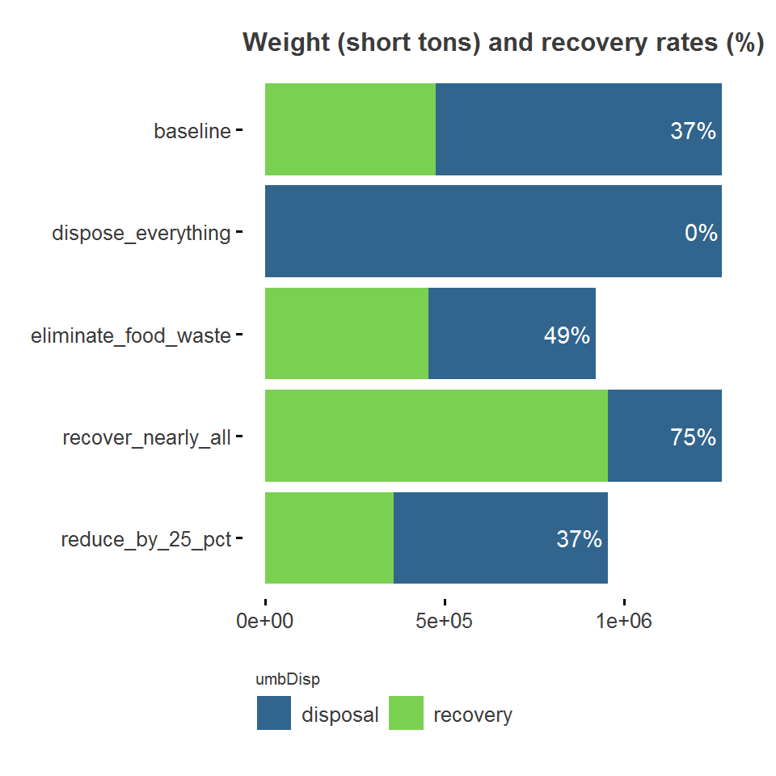

```r
tempWeightChart2 <-
  ggplot()+
  ggtitle("Weight (short tons) and recovery rates (%)")+
  theme_539()+
  geom_bar(
    data = tempWeightData2,
    aes(x = scenario, y= tons, fill= umbDisp),
    color=NA,
    stat="identity"
  )+
  geom_text(
    data=tempWeightData2a,
    aes(x=scenario, y=tons, label=percent(recovRate)),
    hjust=1.1,
    color="white"
  )+
  scale_fill_viridis(
    begin=0.32, end=0.8, option="viridis", discrete = TRUE
    )+
  coord_flip()+
  guides(fill=guide_legend(ncol=2, title.position = "top"))+
  theme(
    rect=element_rect(fill="transparent"),
    plot.title = element_text(size=12),
    legend.position="bottom",
    legend.title = element_text(size=8),
    legend.justification="left"
    )
tempWeightChart2
```

```r
ggsave("chart_output/weights2.png")
```

Now for comparison, let’s look at the impacts associated with those scenarios. Because there are multiple impact categories, I’ll do a faceted chart.

```r
tempImpactData2 <-
  impactsInDetail %>%
  filter(wasteshed=="All cities") %>% # same filtering as weight chart
  group_by(scenario, LCstage, impactCategory, impactUnits) %>%
  summarise(impact=sum(impact)) %>%
  ungroup() %>%
  mutate(
    scenario = factor(scenario, levels = rev(scenarioOrder)),
    impactLabel =
      paste(
        impactCategory,
        " (",
        impactUnits,
        ")",
        sep=""
      ),
    LCstage=
      factor(
        LCstage,
        levels=c("production","endOfLife","endOfLifeTransport")
      )
  ) %>%
  filter(impactCategory != "Energy demand") #removing to save space
```

now make that into a full-page chart

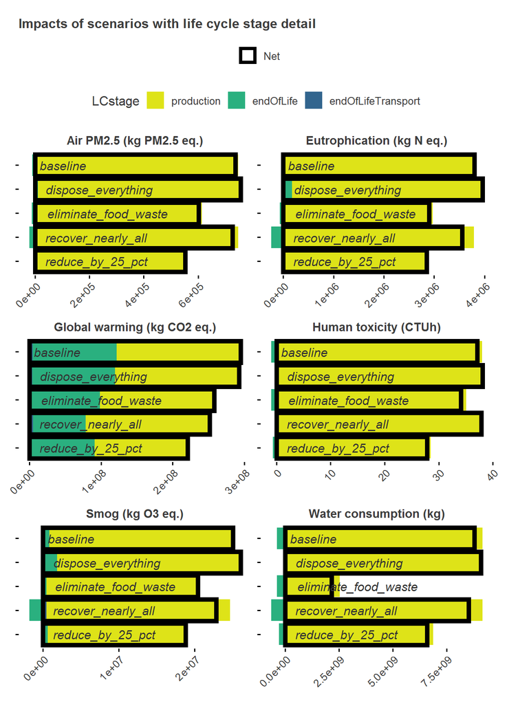

```r
tempImpactChart2 <-
  ggplot()+
  ggtitle("Impacts of scenarios with life cycle stage detail")+
  theme_539()+
  geom_bar(
    data = tempImpactData2,
    aes(x = scenario, y= impact, fill=LCstage),
    color=NA,
    # size=2,
    stat="identity"
  )+
  geom_bar(
    data=tempImpactData1 %>% mutate(LCstage="Net"),
    aes(x=scenario, y=impact, color=LCstage),
    stat="identity",
    fill=NA,
    size=2
  )+
  geom_text(
    data=tempImpactData1 %>% mutate(LCstage="Net"),
    aes(x=scenario, y=0, label=scenario),
    stat="identity",
    color="gray20",
    size=4,
    fontface="italic",
    hjust=-0.1
  )+
  facet_wrap(~impactLabel, ncol=2, scales="free")+
  scale_color_manual(values="black")+
  scale_fill_viridis(
    begin=0.32, end=0.95, option="viridis", discrete = TRUE,
    direction = -1
  )+
  coord_flip()+
  guides(
    color=guide_legend(nrow=1, title=NULL),
    fill=guide_legend(nrow=1, title.position = "left")
    )+
  theme(
    rect=element_rect(fill="transparent"),
    plot.title = element_text(size=12),
    legend.position="top",
    axis.text.x=element_text(angle=45, hjust=1),
    axis.text.y=element_blank(),
    strip.text = element_text(size=11, face="bold")
    )
tempImpactChart2
```

```r
ggsave("chart_output/impacts2.png")
```

Because it’s difficult to look at all these impacts at one time, it may pay to do a heatmap version of the impacts per scenario, where the impacts are all scaled to the baseline scenario.

```r
tempImpactData3 <-
  tempImpactData1 %>%
  filter(scenario=="baseline") %>%
  select(impactLabel, impact) %>%
  rename(baselineImpact=impact)
tempImpactData3a <-
  left_join(
    tempImpactData1,
    tempImpactData3,
    by= c("impactLabel")
  ) %>%
  mutate(
    pctBaselineImpact=impact/baselineImpact
  )
```

now make that into a chart

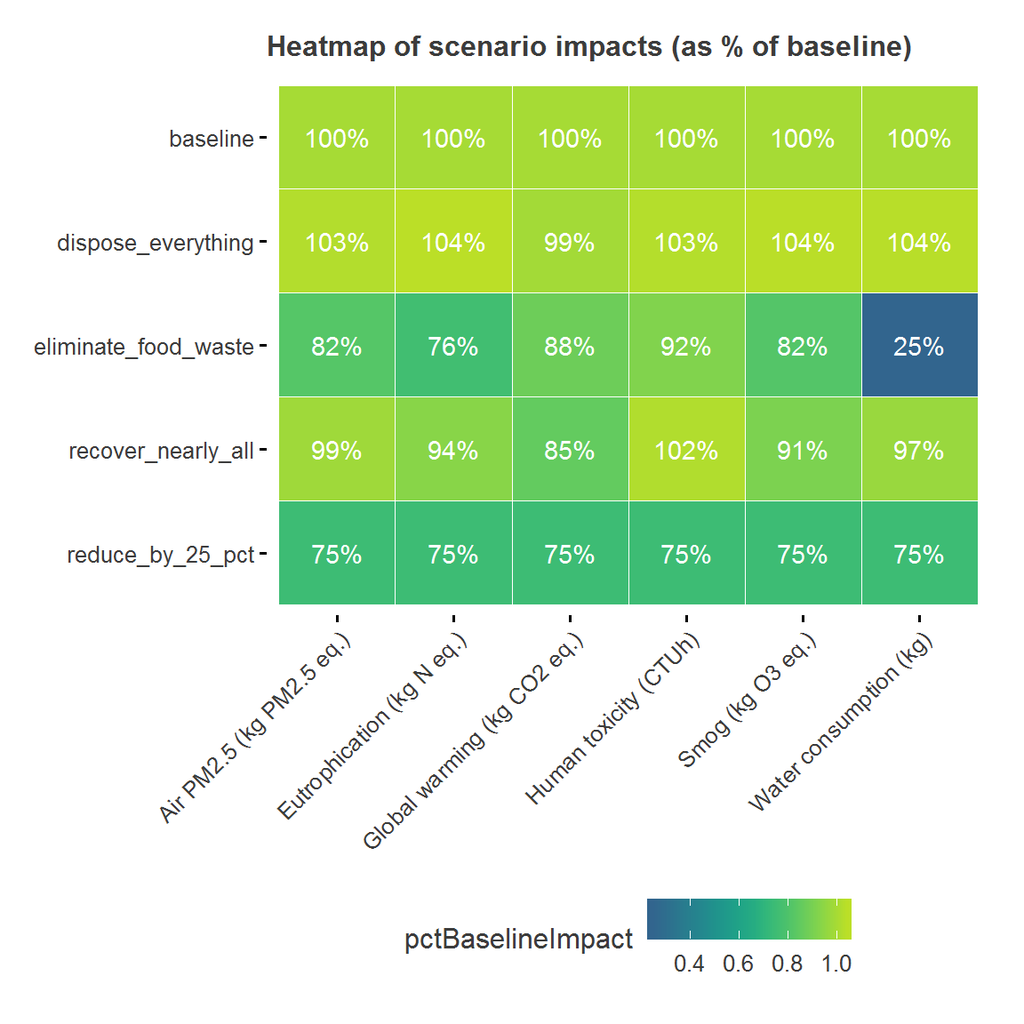

```r
tempImpactChart3 <-
  ggplot()+
  ggtitle("Heatmap of scenario impacts (as % of baseline)")+
  theme_539()+
  geom_tile(
    data=tempImpactData3a,
    aes(y=scenario, x=impactLabel, fill=pctBaselineImpact),
    color="white"
  )+
  geom_text(
    data=tempImpactData3a,
    aes(
      y=scenario, x=impactLabel, label=percent(pctBaselineImpact,1)
    ),
    color="white"
  )+
  scale_fill_viridis(begin=0.32, end=0.9, option="viridis")+
  theme(
    plot.title = element_text(size=12),
    rect=element_rect(fill="transparent"),
    panel.grid = element_blank(),
    axis.ticks = element_line(),
    axis.text.x = element_text(hjust=1, angle=45)
  )
tempImpactChart3
```

```r
ggsave("chart_output/impacts3.png")
```

All this may seem a little unbelievable. It may help to delve into detail for individual materials in individual scenarios. Let’s compare weight and impacts side by side and do it as a giant collection.

```r
tempWeightData4 <-
  impactsInDetail %>%
  filter(LCstage == "endOfLife") %>% # correct set for weight calculations
  group_by(wasteshed, scenario, material, umbDisp) %>%
  summarise(tons=sum(tons)) %>%
  ungroup() %>%
  filter(tons != 0) %>%
  mutate(scenario= factor(scenario, levels=rev(scenarioOrder))) %>%
  mutate(recovTons=ifelse(umbDisp=="recovery",tons,0)) %>%
  mutate(material=factor(material, levels=materialSortOrder))

# creating a data file that expresses weight-based
# recovery rate for each scenario
tempWeightData4a <-
  tempWeightData4 %>%
  group_by(wasteshed, scenario, material) %>%
  summarise(
    recovTons=sum(recovTons),
    tons=sum(tons)
  ) %>%
  ungroup() %>%
  mutate(recovRate=recovTons/tons)

# total weight for the scenario
tempWeightData4b <-
  tempWeightData4a %>%
  group_by(wasteshed, scenario) %>%
  summarise(allTons=sum(tons)) %>%
  ungroup()

# combining that total
tempWeightData4c <-
  full_join(
    tempWeightData4a,
    tempWeightData4b,
    by=c("wasteshed", "scenario")
  ) %>%
  mutate(pctTons=tons/allTons)

# adding impact categories
tempWeightData4d <-
  left_join(
    tempWeightData4c %>% mutate(dummy=1),
    impactLabels %>% mutate(dummy=1),
    by="dummy"
  ) %>%
  select(-dummy) %>%
  filter(impactCategory != "Energy demand")
```

ok, now the impacts

```r
tempImpactData4 <-
  impactsInDetail %>%
  group_by(
    wasteshed,
    scenario,
    material,
    LCstage,
    impactCategory, impactUnits
  ) %>%
  summarise(impact=sum(impact)) %>%
  ungroup() %>%
  mutate(
    scenario = factor(scenario, levels = rev(scenarioOrder)),
    impactLabel =
      paste(
        impactCategory,
        " (",
        impactUnits,
        ")",
        sep=""
      ),
    LCstage=
      factor(
        LCstage,
        levels=c("production","endOfLife","endOfLifeTransport")
      )
  ) %>%
  filter(impactCategory != "Energy demand") #removing to save space

tempImpactData4a <-
  tempImpactData4 %>%
  group_by(
    wasteshed,
    scenario,
    material,
    impactCategory,
    impactUnits,
    impactLabel
  ) %>%
  summarise(impact=sum(impact)) %>%
  ungroup()

tempImpactData4b <-
  tempImpactData4a %>%
  group_by(
    wasteshed, scenario, impactCategory, impactUnits, impactLabel
  ) %>%
  summarise(allImpact=sum(impact)) %>%
  ungroup()

tempImpactData4c <-
  full_join(
    tempImpactData4a,
    tempImpactData4b,
    by=c(
      "wasteshed", "scenario", "impactCategory",
      "impactUnits", "impactLabel"
    )
  ) %>%
  mutate(pctImpact=impact/allImpact)
```

now lining those percentages up into a long, skinny file

```r
weightImpactComparisonData1 <-
  bind_rows(
    tempWeightData4d %>%
      select(scenario, wasteshed, material, pctTons, impactLabel) %>%
      rename(pctTotal=pctTons) %>%
      mutate(dataType="weight"),
    tempImpactData4c %>%
      select(scenario, wasteshed, material, pctImpact, impactLabel) %>%
      rename(pctTotal=pctImpact) %>%
      mutate(dataType="impact")
  ) %>%
  arrange(wasteshed, scenario, material, impactLabel)
```

That’s way too much data to display, but I’ll make a sample selection to compare percentages.

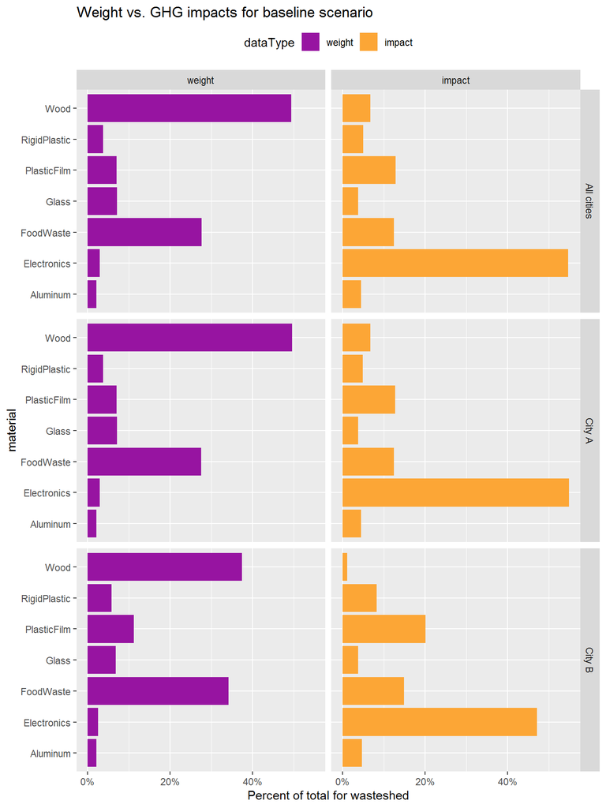

```r
weightImpactComparisonData2 <-
  filter(
    weightImpactComparisonData1,
    scenario=="baseline",
    impactLabel=="Global warming (kg CO2 eq.)"
  ) %>%
  mutate(dataType=factor(dataType, levels=c("weight", "impact")))
ggplot()+
  ggtitle("Weight vs. GHG impacts for baseline scenario")+
  geom_bar(
    data=weightImpactComparisonData2,
    aes(x=material, y=pctTotal, fill=dataType),
    stat="identity",
    color=NA
  )+
  scale_y_continuous(
    name="Percent of total for wasteshed",
    labels=percent
  )+
  scale_fill_viridis(begin = 0.32, end=0.8,
                      discrete=TRUE,
                      option="plasma",
                      direction=1)+
  facet_grid(wasteshed~dataType)+
  coord_flip()+
  theme(
    rect=element_rect(fill="transparent"),
    axis.ticks=element_line(),
    legend.position="top",
    axis.title=element_text()
  )
```

```r
ggsave("chart_output/weight_impact_comparison.png")
```